# COMPSCIX 415.2 Homework 2

##### 4- See below for scatterplot of hwy and cyl:

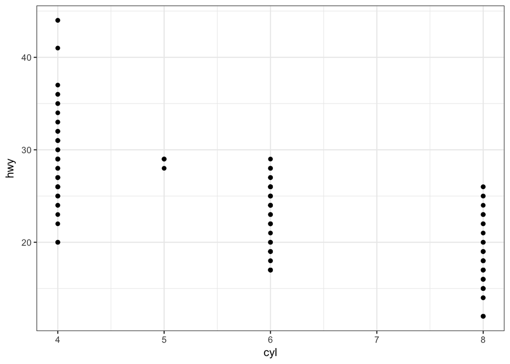

```r
ggplot(data = mpg) + geom_point(mapping = aes(x = cyl, y = hwy)) + theme_bw()
```

##### 5- See below for scatterplot of class and drv. The following graph is not really helpful because it does not show a specific corrolation between the class of the car and how the wheels work. This information can not be used to make a conclusion.

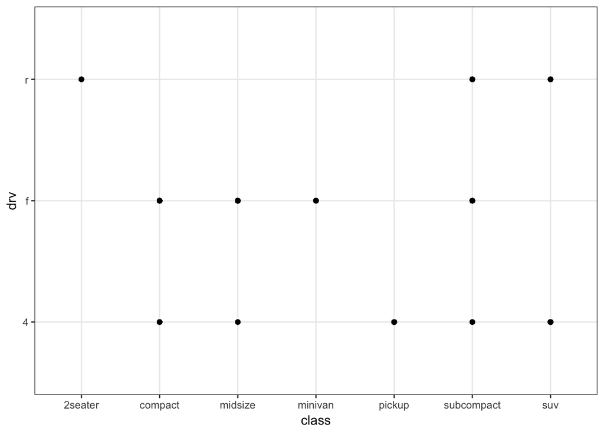

```r
ggplot(data = mpg) + geom_point(mapping = aes(x = class, y = drv)) + theme_bw()
```

### Answers to questions 3.3.1

##### 1- The color in the graph below is not blue because color = “blue” is inside the aesthetics parentheses. r doesn’t recognize “blue” as a variable in this data set.

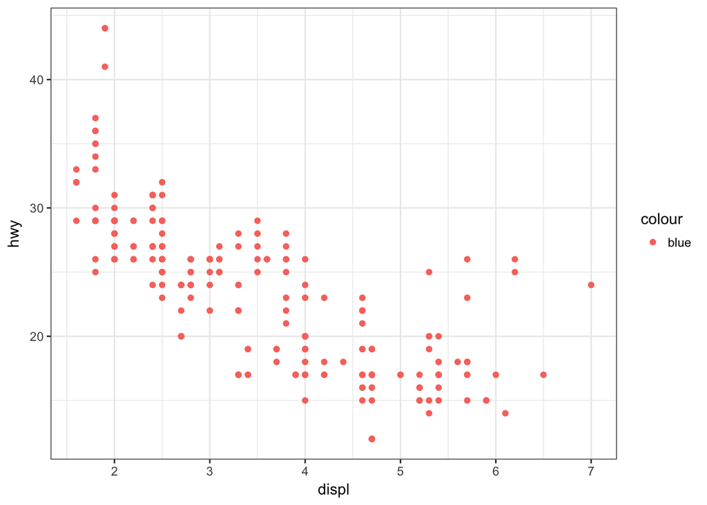

```r
ggplot(data = mpg) + geom_point(mapping = aes(x = displ, y = hwy, color = "blue")) + theme_bw()
```

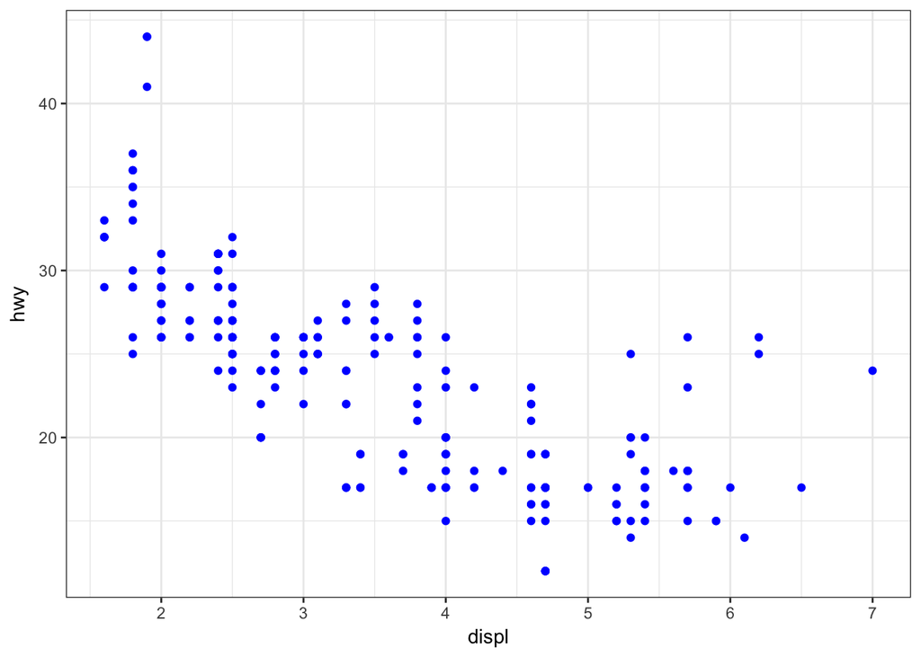

```r
ggplot(data = mpg) + geom_point(mapping = aes(x = displ, y = hwy), color = "blue") +theme_bw()
```

##### 2- Categorical variables are: manufacturer, model, trans, drv, fl, class

##### Continuous variables are: displ, year, cyl, cty, hwy

##### You can find this information by typing ?mpg, or glimpse(mpg)

```r
glimpse(mpg)
```

```
## Observations: 234
## Variables: 11
## $ manufacturer <chr> "audi", "audi", "audi", "audi", "audi", "audi", "...
## $ model        <chr> "a4", "a4", "a4", "a4", "a4", "a4", "a4", "a4 qua...
## $ displ        <dbl> 1.8, 1.8, 2.0, 2.0, 2.8, 2.8, 3.1, 1.8, 1.8, 2.0,...
## $ year         <int> 1999, 1999, 2008, 2008, 1999, 1999, 2008, 1999, 1...
## $ cyl          <int> 4, 4, 4, 4, 6, 6, 6, 4, 4, 4, 4, 6, 6, 6, 6, 6, 6...
## $ trans        <chr> "auto(l5)", "manual(m5)", "manual(m6)", "auto(av)...
## $ drv          <chr> "f", "f", "f", "f", "f", "f", "f", "4", "4", "4",...
## $ cty          <int> 18, 21, 20, 21, 16, 18, 18, 18, 16, 20, 19, 15, 1...
## $ hwy          <int> 29, 29, 31, 30, 26, 26, 27, 26, 25, 28, 27, 25, 2...
## $ fl           <chr> "p", "p", "p", "p", "p", "p", "p", "p", "p", "p",...
## $ class        <chr> "compact", "compact", "compact", "compact", "comp...
```

### 3- The graph with catehorical variable is useful. There are useful corrolations in thise graphs:

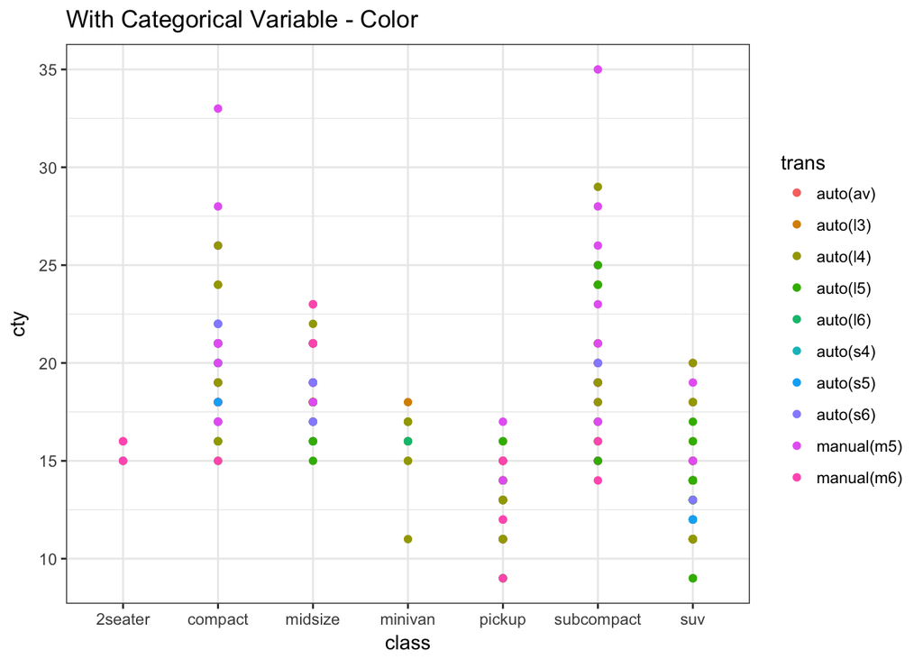

```r
ggplot(data = mpg) + geom_point(mapping = aes(x = class , y = cty, color = trans)) +theme_bw() + ggtitle("With Categorical Variable - Color")
```

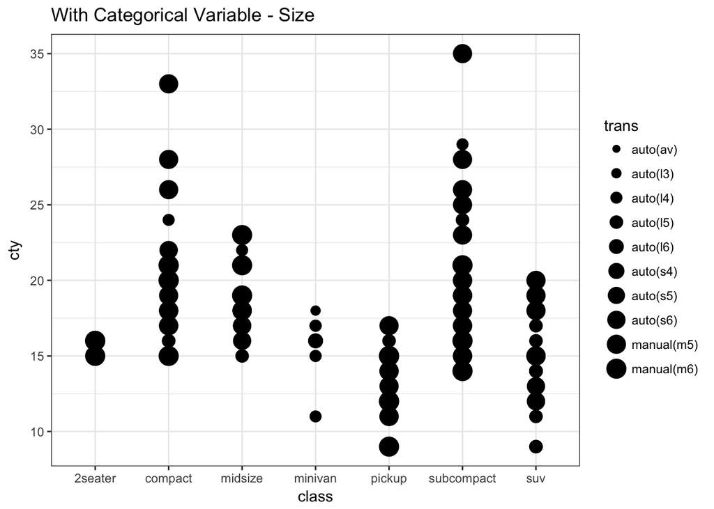

```r
ggplot(data = mpg) + geom_point(mapping = aes(x = class , y = cty, size = trans)) +theme_bw() + ggtitle("With Categorical Variable - Size")
```

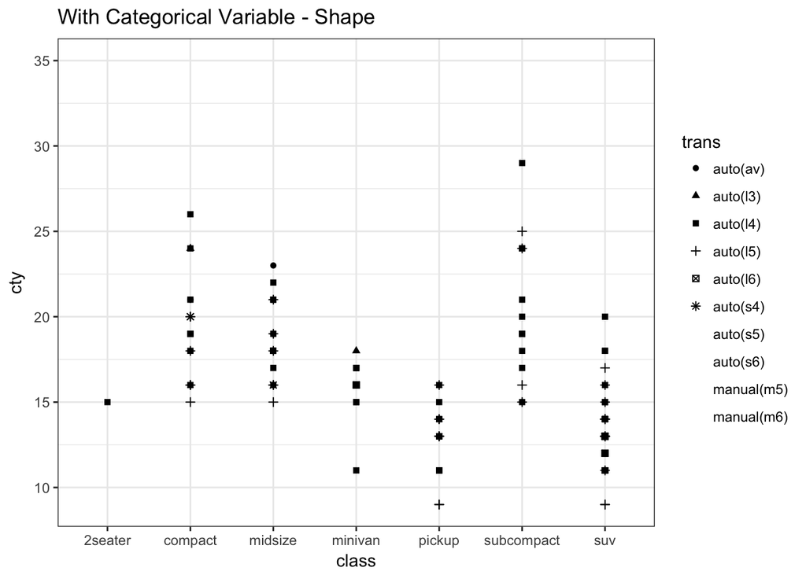

```r
ggplot(data = mpg) + geom_point(mapping = aes(x = class , y = cty, shape = trans)) +theme_bw() + ggtitle("With Categorical Variable - Shape")
```

##### Shape can not be assigned to a continuous variable - R will respond back with an error

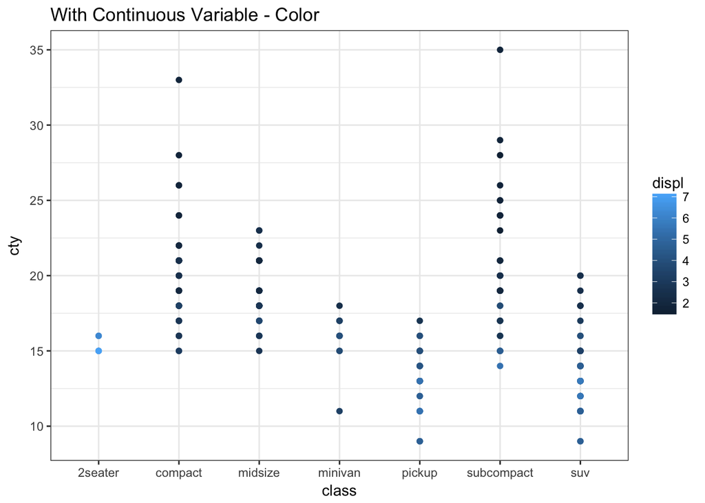

```r
ggplot(data = mpg) + geom_point(mapping = aes(x = class , y = cty, color = displ)) +theme_bw() + ggtitle("With Continuous Variable - Color")
```

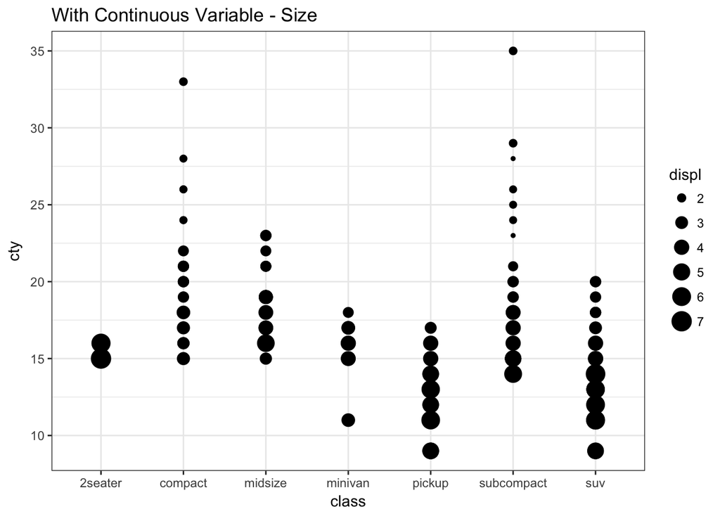

```r
ggplot(data = mpg) + geom_point(mapping = aes(x = class , y = cty, size = displ)) +theme_bw() + ggtitle("With Continuous Variable - Size")
```